# Bayesian Random-Effects Meta-Analysis of Published BCG Vaccine Studies

Author

Akash Bhardwaj

Published

July 20, 2026

## Project objective

This educational project compares frequentist and Bayesian random-effects meta-analysis using published aggregate data from historic studies of BCG vaccination and tuberculosis cases.

The workflow calculates study-level odds ratios, estimates pooled associations and between-study heterogeneity, assesses study influence, fits a Bayesian hierarchical model in Stan, and compares frequentist confidence intervals with Bayesian credible intervals.

## Dataset

The analysis used the `dat.colditz1994` dataset distributed through the R package `metadat`.

The dataset contains 13 historic published studies with aggregate 2×2 event data:

- tuberculosis cases in BCG-vaccinated groups;
- participants without tuberculosis in BCG-vaccinated groups;
- tuberculosis cases in control groups;
- participants without tuberculosis in control groups.

This is an educational re-analysis of historic published aggregate data. It is not a new systematic review, treatment recommendation, regulatory submission, or health technology assessment.

## Study-level effect sizes

Odds ratios were calculated for each study.

An odds ratio below 1 indicates lower odds of tuberculosis cases in the BCG-vaccinated group relative to the control group within that study.

## Frequentist random-effects meta-analysis

A random-effects meta-analysis was fitted using restricted maximum likelihood (REML).

- Studies included: 13
- Pooled odds ratio: 0.475
- 95% confidence interval: 0.330 to 0.683
- Between-study variance, tau-squared: 0.338
- I-squared: 92.1%

### Forest plot

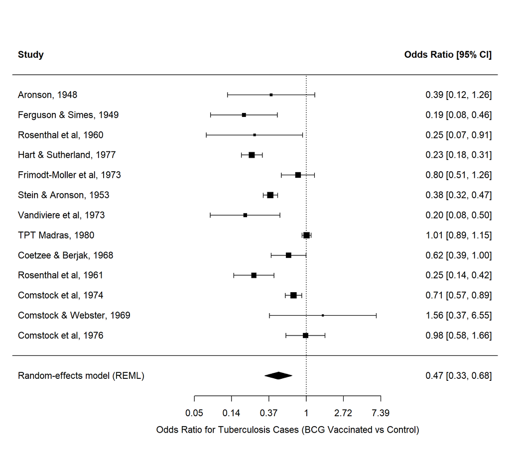

The pooled frequentist estimate was below 1. However, heterogeneity was high, indicating substantial variation in the study-specific estimates.

## Heterogeneity and influence diagnostics

Cochran’s Q statistic was 163.0 with 12 degrees of freedom, with a very small p-value. This was consistent with substantial heterogeneity across studies.

### Baujat plot

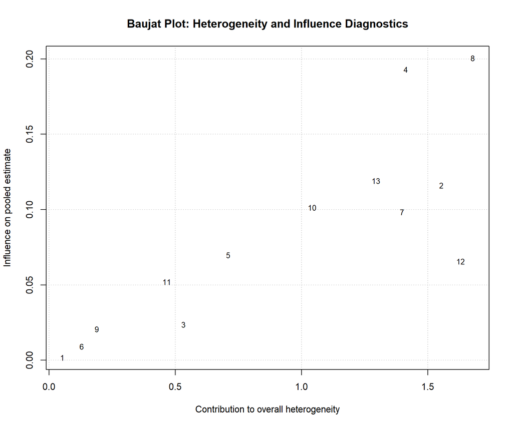

The Baujat plot showed that Study 8 (TPT Madras, 1980) had the strongest combined contribution to heterogeneity and influence on the pooled estimate. Study 4 (Hart and Sutherland, 1977) was also relatively influential.

No studies were excluded solely because of these diagnostics.

Leave-one-out analysis showed that the pooled odds ratio remained below 1 when each study was omitted in turn. Therefore, no individual study alone determined the direction of the pooled association.

## Bayesian random-effects meta-analysis

A Bayesian hierarchical random-effects model was fitted in Stan using four Markov chain Monte Carlo chains.

The model estimated:

- `mu`: pooled log odds ratio;
- `tau`: between-study standard deviation on the log odds-ratio scale;
- study-specific underlying effects.

The priors were:

```
mu ~ Normal(0, 2)
tau ~ Half-Normal(0, 1)
```

### MCMC diagnostics

All four chains completed successfully.

- R-hat values were 1.00 for the pooled effect and heterogeneity parameters.
- Effective sample sizes were high.
- No divergent-transition warnings were reported.

These diagnostics support convergence for this model run.

### Bayesian pooled effect

- Posterior mean pooled odds ratio: 0.488
- 95% credible interval: 0.315 to 0.717
- Posterior mean tau: 0.641
- 95% credible interval for tau: 0.373 to 1.06

### Posterior distribution of pooled odds ratio

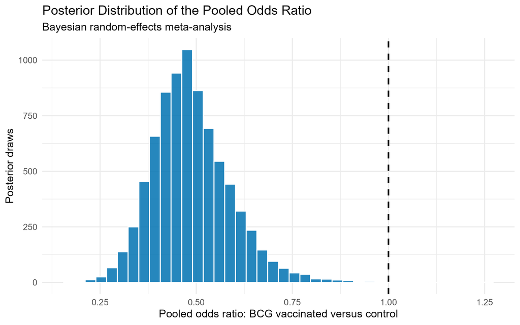

The posterior distribution is concentrated below an odds ratio of 1. Under the specified model and priors, it supports lower odds of tuberculosis cases in BCG-vaccinated groups than in control groups in these historic data.

### Posterior distribution of heterogeneity

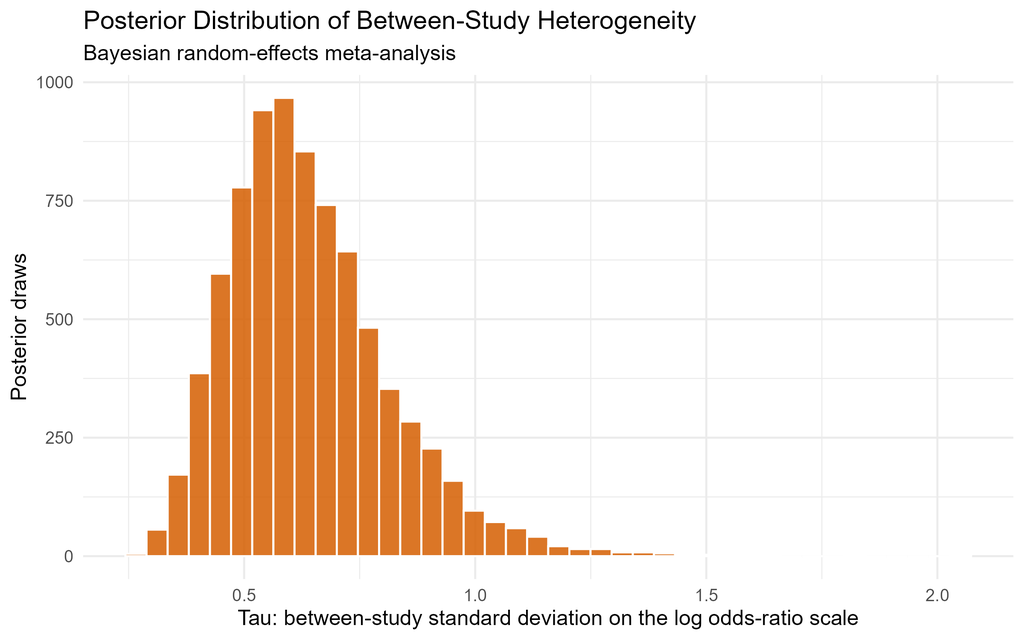

The posterior distribution of tau indicates substantial uncertainty and variation in underlying study effects.

## Frequentist and Bayesian comparison

| Method | Pooled odds ratio | Uncertainty interval |
| --- | --- | --- |
| Frequentist random-effects meta-analysis (REML) | 0.475 | 95% confidence interval: 0.330 to 0.683 |
| Bayesian random-effects meta-analysis (Stan) | 0.488 | 95% credible interval: 0.315 to 0.717 |

The frequentist and Bayesian estimates were similar. Both approaches estimated a pooled odds ratio below 1, while also indicating substantial between-study heterogeneity.

## Reproducibility

Run the R scripts in this order:

```
scripts/01_install_packages.R
scripts/02_load_bcg_data.R
scripts/03_frequentist_random_effects_meta_analysis.R
scripts/04_heterogeneity_and_influence_checks.R
scripts/05_install_cmdstanr.R
scripts/06_bayesian_random_effects_meta_analysis.R
scripts/07_bayesian_visualisations_and_model_comparison.R
```

The Stan model is located at:

```
models/bayesian_random_effects_meta_analysis.stan
```

## Limitations

- This project uses historic published aggregate data from 13 studies.
- It is not a systematic review with a prospectively registered protocol.
- Study-level aggregate data do not allow patient-level adjustment.
- High heterogeneity limits interpretation of a single pooled estimate.
- The Bayesian results depend on the specified model structure and prior distributions.
- The analysis does not assess study quality, publication bias, current BCG policy, current tuberculosis epidemiology, or clinical applicability.
- Results are educational and must not be used for clinical or public-health decision-making.

## Conclusion

This project demonstrates frequentist and Bayesian random-effects meta-analysis in R and Stan.

The frequentist and Bayesian models produced similar pooled odds-ratio estimates while highlighting substantial between-study heterogeneity. The project demonstrates evidence synthesis, uncertainty communication, heterogeneity assessment, Bayesian hierarchical modelling, and reproducible reporting.